# Convertible de SPCX: diagnóstico, valuación, cobertura y griegas

Equipo 2 · Productos Derivados y Administración de Riesgos Corporativos (EGADE)

8 de noviembre de 2026

# Objetivo

Este reporte replica, para SPCX (Space Exploration Technologies Corp.), el tipo de decisión del caso *Molson Coors Brewing Co.: Valuing a Convertible Bond*: financiarse más barato con un bono convertible y cubrir la dilución con un call spread. La idea central es que **convertible = bono recto + opción call**, y que toda mejora del cupón o de la prima de conversión tiene un precio en derivados.

Cada sección trae sus datos, el código, la gráfica o tabla y la interpretación. Las cifras del texto salen del código: si cambian los parámetros de la sección 2, el texto se actualiza.

> **Sobre los datos.** Los precios de SPCX, la estructura de deuda y los comparables vienen de exportes de Refinitiv (LSEG) procesados en `data/processed/`; los vencimientos de principal, de la nota 9 del 10-Q al 30-sep-2026. El spot y la volatilidad implícita son de TradingView (consulta del 8-nov-2026, domingo: reflejan el cierre del viernes 6). Los supuestos del equipo están marcados como tales en la sección 2.

# 1. Datos de la empresa

```r
# El Rmd vive en reports/; los datos procesados, en data/processed/
ruta <- if (dir.exists("../data/processed")) "../data/processed" else "data/processed"
precios <- fromJSON(file.path(ruta, "precios_spcx.json"))$datos
precios$fecha <- as.Date(precios$fecha)
precios <- precios[order(precios$fecha), ]
precios$ret <- c(NA, diff(log(precios$cierre)))
cat("SPCX:", nrow(precios), "cierres diarios, del", format(min(precios$fecha)), "al", format(max(precios$fecha)), "\n")
```

```
## SPCX: 94 cierres diarios, del 2026-06-12 al 2026-10-26
```

```r
tail(precios[, c("fecha", "apertura", "maximo", "minimo", "cierre", "volumen")], 5)
```

|  | fecha | apertura | maximo | minimo | cierre | volumen |
| --- | --- | --- | --- | --- | --- | --- |
| 90 | 2026-10-20 | 146.165 | 148.660 | 143.2700 | 147.79 | 117204886 |
| 91 | 2026-10-21 | 160.555 | 166.180 | 156.9301 | 159.31 | 220785163 |
| 92 | 2026-10-22 | 154.210 | 154.255 | 143.2100 | 144.75 | 197046495 |
| 93 | 2026-10-23 | 147.930 | 149.750 | 144.0850 | 147.49 | 110617461 |
| 94 | 2026-10-26 | 146.840 | 150.240 | 144.5700 | 146.90 | 103184900 |

## 1.1 Precio

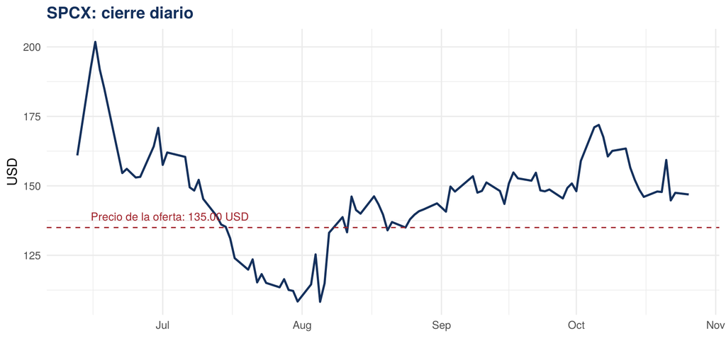

```r
ggplot(precios, aes(fecha, cierre)) +
  geom_line(color = AZUL, linewidth = 0.9) +
  geom_hline(yintercept = 135, linetype = "dashed", color = ROJO) +
  annotate("text", x = min(precios$fecha) + 3, y = 139, label = "Precio de la oferta: 135.00 USD", color = ROJO, hjust = 0, size = 3.5) +
  labs(title = "SPCX: cierre diario", x = NULL, y = "USD")
```

**Interpretación.** SPCX salió a bolsa a 135.00 USD, abrió en 150.00 y cerró el primer día en 160.95. El cierre más alto fue de 201.80 y el más bajo de 108.27. Con tan pocos datos (94 días desde el listado), cualquier estadística de riesgo tiene mucho error de estimación.

## 1.2 Deuda y vencimientos

```r
# Principal vigente por año de vencimiento, nota 9 del 10-Q al 30-sep-2026 (millones de USD)
venc <- data.frame(
  periodo = factor(c("Resto de 2026", "2027", "2028", "2029", "2030", "Después de 2030"),
                   levels = c("Resto de 2026", "2027", "2028", "2029", "2030", "Después de 2030")),
  musd = c(495, 2425, 2867, 3422, 3597, 25200))
cat("Principal total:", fmt(sum(venc$musd), 0), "M USD\n")
```

```
## Principal total: 38,006 M USD
```

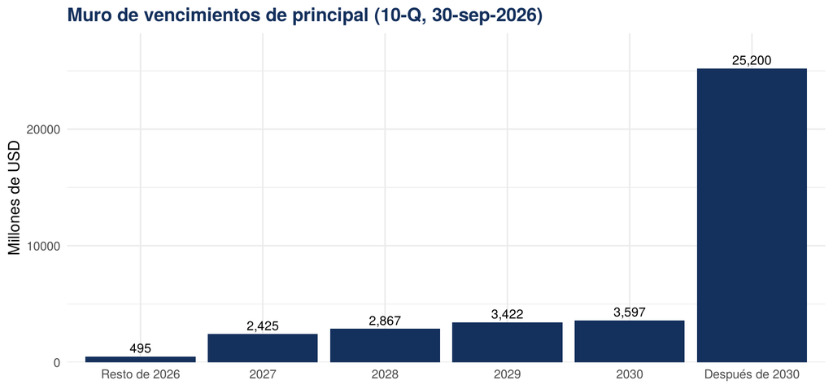

```r
ggplot(venc, aes(periodo, musd)) +
  geom_col(fill = AZUL) +
  geom_text(aes(label = fmt(musd, 0)), vjust = -0.4, size = 3.5) +
  labs(title = "Muro de vencimientos de principal (10-Q, 30-sep-2026)", x = NULL, y = "Millones de USD") +
  scale_y_continuous(expand = expansion(mult = c(0, 0.12)))
```

**Interpretación.** El principal suma 38,006 M USD y 66 % vence después de 2030, casi todo en los SpaceX Notes emitidos en junio de 2026 (25,000 M USD, cupón ponderado de 5.855 %). La deuda de corto plazo es manejable frente a la caja y los valores negociables (89,855 M USD según el 10-Q), así que el convertible no responde a una necesidad de liquidez, sino a bajar el costo de la deuda existente.

## 1.3 Calificaciones

```r
cal <- fromJSON(file.path(ruta, "valuacion.json"))$calificaciones$emisor
knitr::kable(cal, caption = "Calificaciones del emisor (primera calificación de las tres agencias, 19-jun-2026)")
```

Calificaciones del emisor (primera calificación de las tres agencias, 19-jun-2026)

| agencia | calificacion | perspectiva | fecha |
| --- | --- | --- | --- |
| Moody’s | Baa1 | estable | 2026-06-19 |
| Fitch | BBB+ | estable | 2026-06-19 |
| S&P | BBB | estable | 2026-06-19 |

# 2. Parámetros y supuestos

```r
P <- list(
  S      = 134.27,    # precio de la acción, 8-nov-2026 (cierre del viernes 6). Dato de mercado.
  prima  = 0.32,      # prima de conversión. Supuesto del equipo.
  prima_w = 0.60,     # prima del warrant (caso Molson Coors). Supuesto del caso.
  T      = 6,         # plazo en años (caso Molson Coors). Supuesto del caso.
  r      = 0.049,     # UST a 6 años aproximada. Dato de mercado.
  sigma  = 0.4893,    # implícita, call strike 130 que vence el 19-ene-2027 (TradingView). Dato de mercado.
  ytm    = 0.07195,   # yield de los bonos de SPCX a 6 años (Refinitiv, interpolado). Calculado.
  nom    = 1000,      # valor nominal por bono. Supuesto del caso.
  emision = 1000,     # monto de la emisión, millones de USD. Supuesto del equipo.
  circ   = 13579      # acciones en circulación, millones. Dato de mercado.
)
data.frame(parametro = names(P), valor = unlist(P))
```

|  | parametro | valor |
| --- | --- | --- |
| S | S | 1.3427e+02 |
| prima | prima | 3.2000e-01 |
| prima_w | prima_w | 6.0000e-01 |
| T | T | 6.0000e+00 |
| r | r | 4.9000e-02 |
| sigma | sigma | 4.8930e-01 |
| ytm | ytm | 7.1950e-02 |
| nom | nom | 1.0000e+03 |
| emision | emision | 1.0000e+03 |
| circ | circ | 1.3579e+04 |

# 3. Volatilidad

El modelo de Black-Scholes necesita una volatilidad. Se comparan tres estimaciones con la implícita de las opciones listadas.

```r
vol_real <- function(ret, dias = 252) sd(ret, na.rm = TRUE) * sqrt(dias)
vol_ewma <- function(ret, lam = 0.94, dias = 252) {
  ret <- ret[!is.na(ret)]
  v <- var(ret[1:20])
  for (x in ret[-(1:20)]) v <- lam * v + (1 - lam) * x^2
  sqrt(v * dias)
}
vols <- data.frame(
  medida = c("Realizada total", "Realizada últimos 60 días", "EWMA (lambda = 0.94)", "Implícita usada en la valuación"),
  valor = c(vol_real(precios$ret), vol_real(tail(precios$ret, 60)), vol_ewma(precios$ret), P$sigma))
vols$valor_pct <- paste0(fmt(100 * vols$valor, 1), " %")
vols[, c("medida", "valor_pct")]
```

| medida | valor_pct |
| --- | --- |
| Realizada total | 80.3 % |
| Realizada últimos 60 días | 72.7 % |
| EWMA (lambda = 0.94) | 64.1 % |
| Implícita usada en la valuación | 48.9 % |

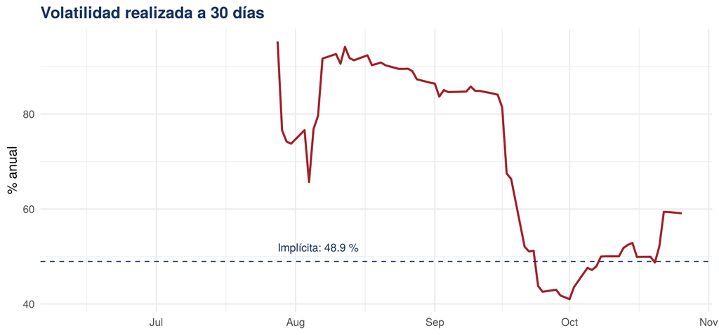

```r
precios$vol30 <- NA
for (i in 31:nrow(precios)) precios$vol30[i] <- vol_real(precios$ret[(i - 29):i])
ggplot(precios, aes(fecha, 100 * vol30)) +
  geom_line(color = ROJO, linewidth = 0.9) +
  geom_hline(yintercept = 100 * P$sigma, linetype = "dashed", color = AZUL) +
  annotate("text", x = min(precios$fecha[!is.na(precios$vol30)]), y = 100 * P$sigma + 3,
           label = paste0("Implícita: ", fmt(100 * P$sigma, 1), " %"), color = AZUL, hjust = 0, size = 3.5) +
  labs(title = "Volatilidad realizada a 30 días", x = NULL, y = "% anual")
```

# 4. Convertible = bono recto + opción

```r
N <- function(x) pnorm(x)
bs_call <- function(S, K, T, r, sg) {
  d1 <- (log(S / K) + (r + 0.5 * sg^2) * T) / (sg * sqrt(T)); d2 <- d1 - sg * sqrt(T)
  S * N(d1) - K * exp(-r * T) * N(d2)
}
valor_bono <- function(cup, ytm, T, nom = 1000, f = 2) {
  n <- round(T * f); i <- ytm / f; k <- 1:n
  sum(cup * nom / f / (1 + i)^k) + nom / (1 + i)^n
}
cupon_eq <- function(objetivo, ytm, T, nom = 1000, f = 2) {   # el valor es lineal en el cupón: solución exacta
  b0 <- valor_bono(0, ytm, T, nom, f); (objetivo - b0) / (valor_bono(1, ytm, T, nom, f) - b0)
}
convertible <- function(S, prima, T, r, sg, ytm, nom = 1000) {
  X <- S * (1 + prima); acc <- nom / X; call <- bs_call(S, X, T, r, sg)
  op <- call * acc
  list(X = X, acciones = acc, call = call, opcion = op, necesario = nom - op,
       cupon_eq = cupon_eq(nom - op, ytm, T, nom))
}
base <- with(P, convertible(S, prima, T, r, sigma, ytm, nom))
data.frame(concepto = c("Precio de conversión (USD)", "Acciones por bono", "Call por acción (USD)", "Opción por bono (USD)",
                        "Bono recto necesario (USD)", "Cupón de equilibrio (%)"),
           valor = c(base$X, base$acciones, base$call, base$opcion, base$necesario, 100 * base$cupon_eq)) |>
  mutate(valor = round(valor, 4))
```

| concepto | valor |
| --- | --- |
| Precio de conversión (USD) | 177.2364 |
| Acciones por bono | 5.6422 |
| Call por acción (USD) | 61.1599 |
| Opción por bono (USD) | 345.0750 |
| Bono recto necesario (USD) | 654.9250 |
| Cupón de equilibrio (%) | 0.0120 |

**Interpretación.** Con una prima de 32 % el precio de conversión es 177.24 USD y cada bono de 1,000 USD da 5.642 acciones. La opción cedida vale 345.08 USD por bono, así que el bono recto debe valer 654.92 USD. A un yield de 7.195 %, eso corresponde a un cupón de equilibrio de 0.01 %: es decir, con esta prima el convertible puede salir a cupón cero y aun así valer el nominal.

## 4.1 Validación contra el caso Molson Coors

```r
mc <- convertible(87.61, 0.25, 6, 0.0446, 0.23, 0.0575)
data.frame(medida = c("Opción por bono (USD)", "Bono recto necesario (USD)", "Cupón de equilibrio (%)"),
           este_codigo = round(c(mc$opcion, mc$necesario, 100 * mc$cupon_eq), 2),
           caso = c(191.5, 808.5, 1.93))
```

| medida | este_codigo | caso |
| --- | --- | --- |
| Opción por bono (USD) | 191.52 | 191.50 |
| Bono recto necesario (USD) | 808.48 | 808.50 |
| Cupón de equilibrio (%) | 1.93 | 1.93 |

```r
stopifnot(abs(mc$opcion - 191.5) < 0.1, abs(mc$cupon_eq - 0.0193) < 1e-4)
```

**Interpretación.** El mismo código con los supuestos del caso reproduce la opción de 191.5 USD y el cupón de equilibrio de 1.93 % del caso, lo que valida las fórmulas antes de aplicarlas a SPCX.

## 4.2 Cupón de equilibrio según la prima y la volatilidad

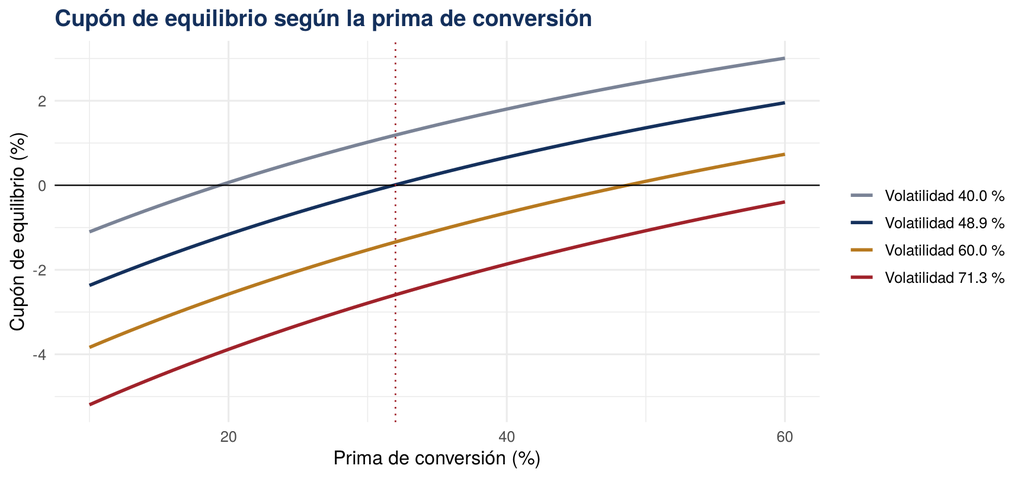

```r
rejilla <- expand.grid(prima = seq(0.10, 0.60, 0.01), sigma = c(0.40, P$sigma, 0.60, 0.713))
rejilla$cupon <- mapply(function(p, s) 100 * convertible(P$S, p, P$T, P$r, s, P$ytm)$cupon_eq, rejilla$prima, rejilla$sigma)
rejilla$vol <- factor(paste0("Volatilidad ", fmt(100 * rejilla$sigma, 1), " %"))
ggplot(rejilla, aes(100 * prima, cupon, color = vol)) +
  geom_line(linewidth = 1) +
  geom_hline(yintercept = 0, color = "black", linewidth = 0.4) +
  geom_vline(xintercept = 100 * P$prima, linetype = "dotted", color = ROJO) +
  scale_color_manual(values = c(GRIS, AZUL, DORADO, ROJO)) +
  labs(title = "Cupón de equilibrio según la prima de conversión", x = "Prima de conversión (%)", y = "Cupón de equilibrio (%)", color = NULL)
```

# 5. Call spread: note hedge y warrants

La empresa compra un call con strike en el precio de conversión (note hedge) y vende un warrant con strike más alto (prima de 60 %, como en el caso). La dilución solo empieza si la acción supera el strike del warrant.

```r
K1 <- base$X
K2 <- P$S * (1 + P$prima_w)
acc <- P$emision / P$nom * P$nom / K1            # millones de acciones subyacentes
costo <- function(sg) {
  c1 <- bs_call(P$S, K1, P$T, P$r, sg); c2 <- bs_call(P$S, K2, P$T, P$r, sg)
  c(call_comprado = c1, warrant_vendido = c2, costo_call_musd = c1 * acc, ingreso_warrants_musd = c2 * acc,
    costo_neto_musd = (c1 - c2) * acc, costo_neto_pct_emision = 100 * (c1 - c2) * acc / P$emision)
}
cs <- t(sapply(c(0.40, P$sigma, 0.60, 0.713), costo))
rownames(cs) <- paste0("vol ", fmt(c(40, 100 * P$sigma, 60, 71.3), 1), " %")
round(cs, 3)
```

```
##            call_comprado warrant_vendido costo_call_musd ingreso_warrants_musd
## vol 40.0 %        51.145          43.212         288.567               243.809
## vol 48.9 %        61.160          54.095         345.075               305.212
## vol 60.0 %        72.687          66.675         410.113               376.193
## vol 71.3 %        83.327          78.320         470.148               441.894
##            costo_neto_musd costo_neto_pct_emision
## vol 40.0 %          44.759                  4.476
## vol 48.9 %          39.863                  3.986
## vol 60.0 %          33.920                  3.392
## vol 71.3 %          28.254                  2.825
```

**Interpretación.** El call spread cuesta 39.9 M USD (4.0 % de la emisión) con la volatilidad base, y se paga una sola vez. A cambio, la prima efectiva pasa de 32 % a 60 %: la dilución empieza en 214.83 USD y no en 177.24 USD. Las 5.64 M de acciones subyacentes equivalen a 0.042 % de las acciones en circulación.

# 6. Escenarios al vencimiento

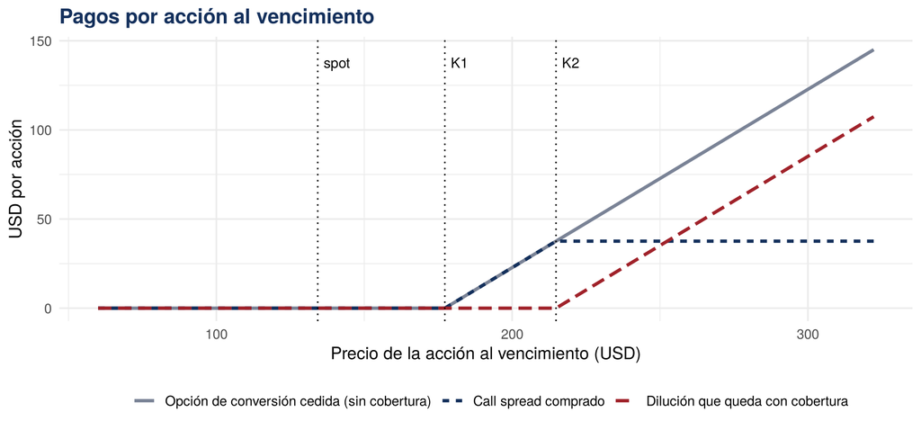

```r
ST <- seq(60, 1.5 * K2, length.out = 300)
pagos <- data.frame(ST = ST,
  conversion = pmax(ST - K1, 0),
  spread = pmin(pmax(ST - K1, 0), K2 - K1))
pagos$dilucion <- pagos$conversion - pagos$spread
largo <- tidyr::pivot_longer(pagos, -ST, names_to = "serie", values_to = "usd")
largo$serie <- factor(largo$serie, c("conversion", "spread", "dilucion"),
                      c("Opción de conversión cedida (sin cobertura)", "Call spread comprado", "Dilución que queda con cobertura"))
ggplot(largo, aes(ST, usd, color = serie, linetype = serie)) +
  geom_line(linewidth = 1.1) +
  geom_vline(xintercept = c(P$S, K1, K2), linetype = "dotted") +
  annotate("text", x = c(P$S, K1, K2) + 2, y = max(pagos$conversion) * 0.95, label = c("spot", "K1", "K2"), hjust = 0, size = 3.5) +
  scale_color_manual(values = c(GRIS, AZUL, ROJO)) +
  labs(title = "Pagos por acción al vencimiento", x = "Precio de la acción al vencimiento (USD)", y = "USD por acción", color = NULL, linetype = NULL) +
  theme(legend.position = "bottom")
```

```r
niveles <- c(60, 100, P$S, K1, 200, K2, 250, 300, 400)
data.frame(
  precio_vto = niveles,
  valor_por_bono = pmax(P$nom, niveles * P$nom / K1),
  costo_sin_cobertura_musd = pmax(niveles - K1, 0) * acc,
  costo_con_cobertura_musd = pmax(niveles - K2, 0) * acc,
  acciones_nuevas_con_cobertura_m = ifelse(niveles > K2, acc * (1 - K2 / niveles), 0)) |>
  mutate(across(everything(), ~ round(.x, 2)))
```

| precio_vto | valor_por_bono | costo_sin_cobertura_musd | costo_con_cobertura_musd | acciones_nuevas_con_cobertura_m |
| --- | --- | --- | --- | --- |
| 60.00 | 1000.00 | 0.00 | 0.00 | 0.00 |
| 100.00 | 1000.00 | 0.00 | 0.00 | 0.00 |
| 134.27 | 1000.00 | 0.00 | 0.00 | 0.00 |
| 177.24 | 1000.00 | 0.00 | 0.00 | 0.00 |
| 200.00 | 1128.44 | 128.44 | 0.00 | 0.00 |
| 214.83 | 1212.12 | 212.12 | 0.00 | 0.00 |
| 250.00 | 1410.55 | 410.55 | 198.42 | 0.79 |
| 300.00 | 1692.65 | 692.65 | 480.53 | 1.60 |
| 400.00 | 2256.87 | 1256.87 | 1044.75 | 2.61 |

**Interpretación.** Si la acción termina por debajo de 177.24 USD, el convertible se paga a la par y no hay dilución. Entre 177.24 y 214.83 USD el note hedge compensa lo que se paga de más; arriba de 214.83 USD la empresa asume el exceso a través de los warrants. Sin la cobertura, cada dólar por encima de 177.24 USD se convierte en costo para el emisor.

# 7. Griegas

```r
griegas <- function(S, K, T, r, sg) {
  d1 <- (log(S / K) + (r + 0.5 * sg^2) * T) / (sg * sqrt(T)); d2 <- d1 - sg * sqrt(T)
  c(delta = N(d1), gamma = dnorm(d1) / (S * sg * sqrt(T)), vega_punto = S * dnorm(d1) * sqrt(T) / 100,
    theta_dia = (-S * dnorm(d1) * sg / (2 * sqrt(T)) - r * K * exp(-r * T) * N(d2)) / 365)
}
g1 <- griegas(P$S, K1, P$T, P$r, P$sigma)   # opción de conversión y note hedge (mismo strike)
g2 <- griegas(P$S, K2, P$T, P$r, P$sigma)   # warrant
pos <- rbind(
  "Opción de conversión vendida" = -acc * g1,
  "Note hedge comprado"          =  acc * g1,
  "Warrants vendidos"            = -acc * g2)
pos <- rbind(pos, "Posición neta con cobertura" = colSums(pos), "Posición sin cobertura" = pos[1, ])
round(pos, 4)
```

```
##                                delta   gamma vega_punto theta_dia
## Opción de conversión vendida -4.1190 -0.0116    -6.1353    0.0965
## Note hedge comprado           4.1190  0.0116     6.1353   -0.0965
## Warrants vendidos            -3.8057 -0.0126    -6.6829    0.1023
## Posición neta con cobertura  -3.8057 -0.0126    -6.6829    0.1023
## Posición sin cobertura       -4.1190 -0.0116    -6.1353    0.0965
```

**Interpretación.** En millones de acciones y de USD por punto de volatilidad y por día. La opción de conversión vendida deja al emisor con una delta de -4.12 M de acciones y vega de -6.14 M USD por punto de volatilidad. El note hedge comprado la neutraliza; con cobertura solo queda la exposición del warrant vendido (delta de -3.81 M de acciones, vega de -6.68 M USD por punto): una subida fuerte del precio o de la volatilidad le cuesta al emisor por encima de 214.83 USD. La theta es positiva (0.102 M USD por día): el paso del tiempo juega a favor del emisor.

# 8. Árbol binomial (CRR)

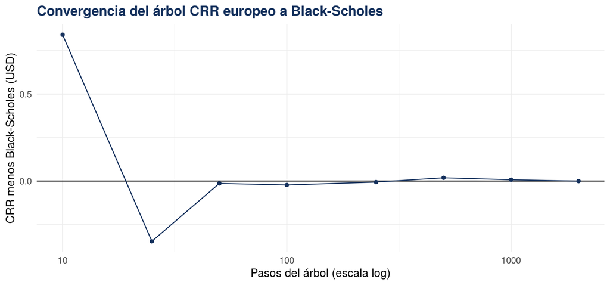

```r
crr <- function(S, K, T, r, sg, N, tipo = "call", americana = FALSE) {
  dt <- T / N; u <- exp(sg * sqrt(dt)); d <- 1 / u; p <- (exp(r * dt) - d) / (u - d); disc <- exp(-r * dt)
  sgn <- if (tipo == "call") 1 else -1
  V <- pmax(sgn * (S * u^(N:0) * d^(0:N) - K), 0)
  for (i in (N - 1):0) {
    cont <- disc * (p * V[1:(i + 1)] + (1 - p) * V[2:(i + 2)])
    if (americana) V <- pmax(cont, pmax(sgn * (S * u^(i:0) * d^(0:i) - K), 0)) else V <- cont
  }
  V[1]
}
Ns <- c(10, 25, 50, 100, 250, 500, 1000, 2000)
conv <- data.frame(N = Ns, crr = sapply(Ns, function(n) crr(P$S, K1, P$T, P$r, P$sigma, n)))
conv$bs <- bs_call(P$S, K1, P$T, P$r, P$sigma)
conv$dif <- conv$crr - conv$bs
ggplot(conv, aes(N, dif)) +
  geom_hline(yintercept = 0) + geom_line(color = AZUL) + geom_point(color = AZUL) +
  scale_x_log10() +
  labs(title = "Convergencia del árbol CRR europeo a Black-Scholes", x = "Pasos del árbol (escala log)", y = "CRR menos Black-Scholes (USD)")
```

```r
round(conv, 4)
```

| N | crr | bs | dif |
| --- | --- | --- | --- |
| 10 | 62.0013 | 61.1599 | 0.8414 |
| 25 | 60.8135 | 61.1599 | -0.3464 |
| 50 | 61.1463 | 61.1599 | -0.0136 |
| 100 | 61.1373 | 61.1599 | -0.0225 |
| 250 | 61.1538 | 61.1599 | -0.0061 |
| 500 | 61.1785 | 61.1599 | 0.0186 |
| 1000 | 61.1672 | 61.1599 | 0.0074 |
| 2000 | 61.1595 | 61.1599 | -0.0004 |

**Interpretación.** El call europeo a 6 años con strike 177.24 USD vale 61.16 USD en Black-Scholes; el árbol converge a ese valor (diferencia de 0.0004 USD con 2,000 pasos). La convergencia oscila, como es normal en el CRR, según la posición del strike en el árbol.

## 8.1 Put americana y prima por ejercicio anticipado

```r
S0 <- 159.31; K0 <- 160; T0 <- 30 / 365; r0 <- 0.0509; sg0 <- 0.5991   # cadena del 21-oct-2026, tarea de clase
eu <- crr(S0, K0, T0, r0, sg0, 500, "put", FALSE)
am <- crr(S0, K0, T0, r0, sg0, 500, "put", TRUE)
data.frame(opcion = c("Put europea (CRR 500)", "Put americana (CRR 500)", "Prima por ejercicio anticipado"),
           usd = round(c(eu, am, am - eu), 4))
```

| opcion | usd |
| --- | --- |
| Put europea (CRR 500) | 10.9178 |
| Put americana (CRR 500) | 10.9623 |
| Prima por ejercicio anticipado | 0.0445 |

**Interpretación.** La put americana vale 0.045 USD más que la europea (0.41 %). Es la prima por poder ejercer antes, que Black-Scholes no captura; sube con la tasa libre de riesgo y con la profundidad *in-the-money*.

# 9. Conclusiones y supuestos abiertos

1. Con los supuestos del 8-nov, el convertible a 6 años con prima de 32 % puede emitirse con cupón de 0.01 %, cediendo una opción de 345 USD por bono, y el call spread cuesta 39.9 M USD.
2. El resultado depende de la volatilidad: con la implícita sale cupón cero; con una volatilidad mayor, la opción cedida vale más de lo que se necesita.
3. Supuestos que siguen abiertos: la prima de conversión y el monto de la emisión son supuestos del equipo; la volatilidad implícita de plazos largos viene de pantalla y no de una superficie completa; el tratamiento contable (utilidad por acción diluida) debe confirmarse con contabilidad.

```r
sessionInfo()$R.version$version.string
```

```
## [1] "R version 4.3.3 (2024-02-29)"
```